# Fire

Xinlu Jiang

2026-04-13

```r
library(car);library(lmtest);library(skedastic);library(sandwich);
```

## Introduction to “Fire”

This data set contains measurements on 270 forest fires in the northeast region of Portugal.

```r
df = read.table("fire.txt", header = TRUE)
summary(df)
```

```
##        X               Y            month               day
##  Min.   :1.000   Min.   :2.000   Length:270         Length:270
##  1st Qu.:3.000   1st Qu.:4.000   Class :character   Class :character
##  Median :5.000   Median :4.000   Mode  :character   Mode  :character
##  Mean   :4.807   Mean   :4.367
##  3rd Qu.:7.000   3rd Qu.:5.000
##  Max.   :9.000   Max.   :9.000
##       FFMC            DMC              DC             ISI
##  Min.   :63.50   Min.   :  3.2   Min.   : 15.3   Min.   : 0.800
##  1st Qu.:90.33   1st Qu.: 82.9   1st Qu.:486.5   1st Qu.: 6.800
##  Median :91.70   Median :111.7   Median :665.6   Median : 8.400
##  Mean   :91.03   Mean   :114.7   Mean   :570.9   Mean   : 9.177
##  3rd Qu.:92.97   3rd Qu.:141.3   3rd Qu.:721.3   3rd Qu.:11.375
##  Max.   :96.20   Max.   :291.3   Max.   :860.6   Max.   :22.700
##       temp             RH             wind            area
##  Min.   : 2.20   Min.   :15.00   Min.   :0.400   Min.   :   0.09
##  1st Qu.:16.12   1st Qu.:33.00   1st Qu.:2.700   1st Qu.:   2.14
##  Median :20.10   Median :41.00   Median :4.000   Median :   6.37
##  Mean   :19.31   Mean   :43.73   Mean   :4.113   Mean   :  24.60
##  3rd Qu.:23.40   3rd Qu.:53.00   3rd Qu.:4.900   3rd Qu.:  15.42
##  Max.   :33.30   Max.   :96.00   Max.   :9.400   Max.   :1090.84
```

Our response variable is `area`, by our first eye, we noticed that it has a median of 6.37, a mean of 24.6, while the 3rd qu of 15.42, indicating that it does not follow normal distribution for sure and we might transform it into log form in the future.

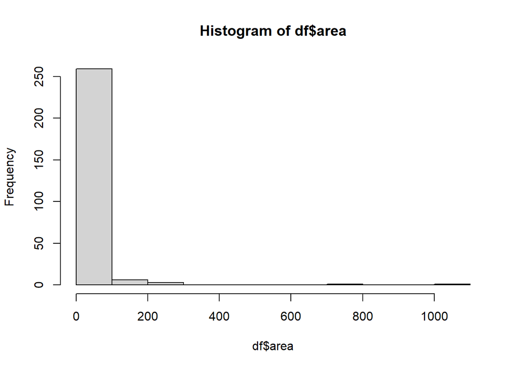

```r
hist(df$area)
```

Quantitative covariates includes `FFMC`, `DMC`, `DC`, `ISI`, `temp`, `RH`, `wind`, and location information `X` and `Y`. While the rest, `month` and `day` are qualitative variables that will be used later for fixed/random effects.

## Basic Model

### OLS and tests

```r
# We preserve quantitative covirates at this stage
df_quant = subset(df, select = -c(month,day))
ols_model = lm(area ~ ., df_quant)
summary(ols_model)
```

```
##
## Call:
## lm(formula = area ~ ., data = df_quant)
##
## Residuals:
##     Min      1Q  Median      3Q     Max
##  -72.60  -26.21  -12.28    1.12 1046.15
##
## Coefficients:
##              Estimate Std. Error t value Pr(>|t|)
## (Intercept) -43.41569  207.18386  -0.210    0.834
## X             3.17687    2.60343   1.220    0.223
## Y            -0.65104    5.27495  -0.123    0.902
## FFMC          0.58618    2.33019   0.252    0.802
## DMC           0.15223    0.13098   1.162    0.246
## DC           -0.01254    0.03244  -0.387    0.699
## ISI          -1.97004    1.95091  -1.010    0.314
## temp          1.15236    1.40136   0.822    0.412
## RH           -0.51706    0.44890  -1.152    0.250
## wind          2.51915    3.15305   0.799    0.425
##
## Residual standard error: 86.49 on 260 degrees of freedom
## Multiple R-squared:  0.03365,    Adjusted R-squared:  0.0001997
## F-statistic: 1.006 on 9 and 260 DF,  p-value: 0.4355
```

We notice that no covariates shows statistical significance at this stage, and the adjusted R-squared is very low.

Our required linear constrain to test is
$$H_0:50\beta_{DHC}+10\beta_{RH}=6\beta_{lSl}+12\beta_{temp}=3.$$

```r
constraints <- c("50*DC + 10*RH = 3",
                 "6*ISI + 12*temp = 3")
f_test <- linearHypothesis(ols_model, constraints, test = "F")
print(f_test)
```

```
##
## Linear hypothesis test:
## 50 DC  + 10 RH = 3
## 6 ISI  + 12 temp = 3
##
## Model 1: restricted model
## Model 2: area ~ X + Y + FFMC + DMC + DC + ISI + temp + RH + wind
##
##   Res.Df     RSS Df Sum of Sq     F Pr(>F)
## 1    262 1973393
## 2    260 1945070  2     28323 1.893 0.1527
```

```r
wald_test <- linearHypothesis(ols_model, constraints, test = "Chisq")
print(wald_test)
```

```
##
## Linear hypothesis test:
## 50 DC  + 10 RH = 3
## 6 ISI  + 12 temp = 3
##
## Model 1: restricted model
## Model 2: area ~ X + Y + FFMC + DMC + DC + ISI + temp + RH + wind
##
##   Res.Df     RSS Df Sum of Sq Chisq Pr(>Chisq)
## 1    262 1973393
## 2    260 1945070  2     28323 3.786     0.1506
```

The results from Exact F test and Asymptomatic Wald test agree each other and show that we cannot reject the null hypothesis. The Chisq statistic is about two times of F statistic, as the two has a difference of 2 degrees of freedom. Score test and LR test are both asymptomatic test, and similar to Wald test. The only difference between Wald test and Score test is the variance they use.

### Heteroscedasticity

We need homoscedasticity to calculate a valid OLS SE, so we can plot a scatter plot to watch it, or use BP test as well. We found out a easier way to draw the residual plots by https://rpubs.com/sharmaar3/Residual_Plots.

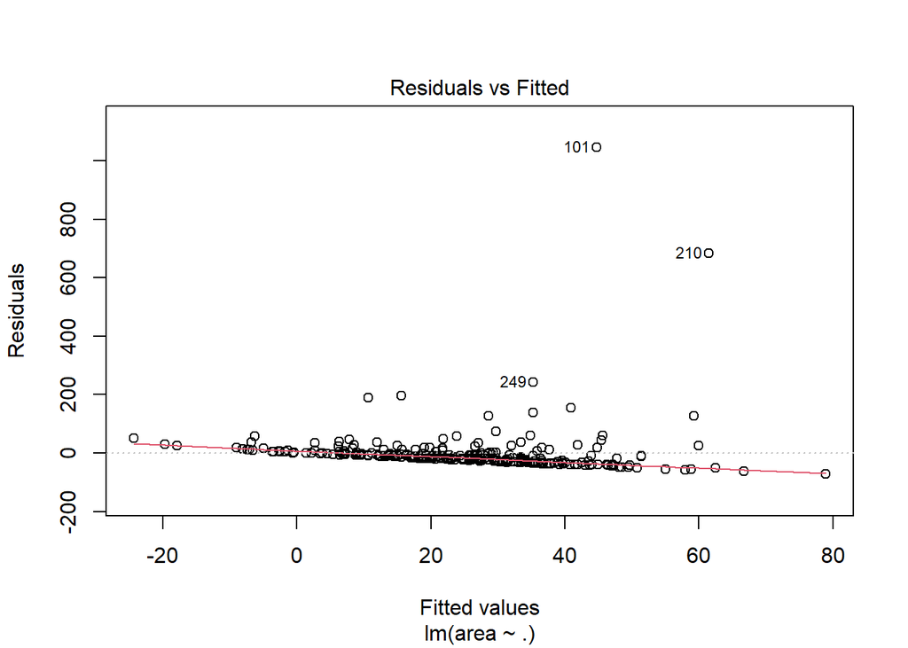

```r
plot(ols_model, which = 1)
```

From the plot, we are surprised to find that there is no significant heteroscedasticity. We use test to verify our observation from the plot.

```r
bp_test_result = bptest(ols_model)
print(bp_test_result)
```

```
##
##  studentized Breusch-Pagan test
##
## data:  ols_model
## BP = 5.4, df = 9, p-value = 0.7981
```

```r
squared_residuals <- resid(ols_model)^2

df_quant2 = subset(df_quant, select = -area)
aux_model <- lm(squared_residuals ~ .^2 + I(as.matrix(df_quant2)^2), data = df_quant2)
# We could also include interaction here if needed
r_sq <- summary(aux_model)$r.squared
n <- nrow(df_quant2)
lm_stat <- n * r_sq
p_val <- pchisq(lm_stat, df = aux_model$rank - 1, lower.tail = FALSE)
print(p_val)
```

```
## [1] 0.9999738
```

```r
white(ols_model)
```

```
## # A tibble: 1 × 5
##   statistic p.value parameter method       alternative
##       <dbl>   <dbl>     <dbl> <chr>        <chr>
## 1      8.15   0.976        18 White's Test greater
```

After all, at this stage, the variance of the random error terms non-constant is not a function of any of the quantitative covariates.

## Robust Standard Errors

```r
se_ols <- sqrt(diag(vcov(ols_model)))
se_hc3 <- sqrt(diag(vcovHC(ols_model, type = "HC3")))

compare_se <- data.frame(
  Variable = names(se_ols),
  OLS_SE = se_ols,
  HC3_SE = se_hc3
  )

print(compare_se)
```

```
##                Variable       OLS_SE     HC3_SE
## (Intercept) (Intercept) 207.18385621 87.9218824
## X                     X   2.60342581  1.9016989
## Y                     Y   5.27494704  3.6134407
## FFMC               FFMC   2.33018603  0.9959919
## DMC                 DMC   0.13098417  0.1325100
## DC                   DC   0.03244467  0.0172751
## ISI                 ISI   1.95090751  1.3796752
## temp               temp   1.40136388  1.0014072
## RH                   RH   0.44890020  0.3688818
## wind               wind   3.15305006  1.9740751
```

Different from what we learned, the HC3 SE is even smaller than OLS SE.

```r
robust_t_test <- coeftest(ols_model, vcov = vcovHC(ols_model, type = "HC3"))
print(robust_t_test)
```

```
##
## t test of coefficients:
##
##               Estimate Std. Error t value Pr(>|t|)
## (Intercept) -43.415688  87.921882 -0.4938  0.62187
## X             3.176868   1.901699  1.6705  0.09602 .
## Y            -0.651038   3.613441 -0.1802  0.85716
## FFMC          0.586179   0.995992  0.5885  0.55668
## DMC           0.152229   0.132510  1.1488  0.25169
## DC           -0.012543   0.017275 -0.7261  0.46843
## ISI          -1.970044   1.379675 -1.4279  0.15452
## temp          1.152358   1.001407  1.1507  0.25090
## RH           -0.517056   0.368882 -1.4017  0.16220
## wind          2.519146   1.974075  1.2761  0.20305
## ---
## Signif. codes:  0 '***' 0.001 '**' 0.01 '*' 0.05 '.' 0.1 ' ' 1
```

```r
summary(ols_model)
```

```
##
## Call:
## lm(formula = area ~ ., data = df_quant)
##
## Residuals:
##     Min      1Q  Median      3Q     Max
##  -72.60  -26.21  -12.28    1.12 1046.15
##
## Coefficients:
##              Estimate Std. Error t value Pr(>|t|)
## (Intercept) -43.41569  207.18386  -0.210    0.834
## X             3.17687    2.60343   1.220    0.223
## Y            -0.65104    5.27495  -0.123    0.902
## FFMC          0.58618    2.33019   0.252    0.802
## DMC           0.15223    0.13098   1.162    0.246
## DC           -0.01254    0.03244  -0.387    0.699
## ISI          -1.97004    1.95091  -1.010    0.314
## temp          1.15236    1.40136   0.822    0.412
## RH           -0.51706    0.44890  -1.152    0.250
## wind          2.51915    3.15305   0.799    0.425
##
## Residual standard error: 86.49 on 260 degrees of freedom
## Multiple R-squared:  0.03365,    Adjusted R-squared:  0.0001997
## F-statistic: 1.006 on 9 and 260 DF,  p-value: 0.4355
```

The robust t test shows a even better result, though non of the covariates are statistical significant.

```r
robust_ci <- coefci(ols_model, vcov = vcovHC(ols_model, type = "HC3"), level = 0.95)
print("---hc3 vcov---")
```

```
## [1] "---hc3 vcov---"
```

```r
print(robust_ci)
```

```
##                     2.5 %       97.5 %
## (Intercept) -216.54530488 129.71392822
## X             -0.56782387   6.92156074
## Y             -7.76637263   6.46429654
## FFMC          -1.37505828   2.54741676
## DMC           -0.10870043   0.41315856
## DC            -0.04656036   0.02147348
## ISI           -4.68680360   0.74671617
## temp          -0.81954254   3.12425952
## RH            -1.24343206   0.20932035
## wind          -1.36806481   6.40635620
```

```r
ols_ci <- confint(ols_model, level = 0.95)
print("---ols(hc0) vcov---")
```

```
## [1] "---ols(hc0) vcov---"
```

```r
print(ols_ci)
```

```
##                     2.5 %       97.5 %
## (Intercept) -451.38763579 364.55625914
## X             -1.94961543   8.30335231
## Y            -11.03809453   9.73601844
## FFMC          -4.00225998   5.17461845
## DMC           -0.10569580   0.41015392
## DC            -0.07643121   0.05134432
## ISI           -5.81163422   1.87154679
## temp          -1.60710917   3.91182615
## RH            -1.40099872   0.36688700
## wind          -3.68961978   8.72791117
```

Similarly, the 95% robust CIs are smaller than the CIs from OLS.

## Bootstrap

### Jackknife

```r
n = dim(df_quant)[1]
p = dim(df_quant)[2]

beta = ols_model$coefficients
SE_ols = summary(ols_model)$coefficients[, 2]

# Jackknife
betajack = matrix(0, n, p)
for (i in 1:n)
{
  jack = lm(area ~ ., df_quant[-i, ])
  betajack[i,] = jack$coefficients
}

SE_jack = apply(betajack, 2, sd) * sqrt((n - 1)^2 / n)

# Bootstrap
nboot = 10000
betaboot = matrix(0, nboot, p)
for (k in 1:nboot)
{
  boot = lm(area ~ ., df_quant[sample(n, replace = TRUE), ])
  betaboot[k,] = boot$coefficients
}
betabar_boot = colMeans(betaboot)
# Calculate Bootstrap SE
SE_boot = apply(betaboot, 2, sd)

se_comparison <- data.frame(
  Variable = names(SE_ols),
  OLS_SE = SE_ols,
  Jackknife_SE = SE_jack,
  Bootstrap_SE = SE_boot
)

print(se_comparison)
```

```
##                Variable       OLS_SE Jackknife_SE Bootstrap_SE
## (Intercept) (Intercept) 207.18385621  87.75890250 102.10873515
## X                     X   2.60342581   1.89817191   1.88904366
## Y                     Y   5.27494704   3.60674085   3.64167080
## FFMC               FFMC   2.33018603   0.99414546   1.15181202
## DMC                 DMC   0.13098417   0.13226439   0.13135021
## DC                   DC   0.03244467   0.01724307   0.01730384
## ISI                 ISI   1.95090751   1.37711435   1.42277667
## temp               temp   1.40136388   0.99955017   1.02351127
## RH                   RH   0.44890020   0.36819711   0.36412490
## wind               wind   3.15305006   1.97041010   2.02298646
```

For most covirates, OLS_SE is larger than the SE of jackknife and bootstrap, while the latter two is about the same.

```r
alpha = 0.05

ci_ols <- confint(ols_model, level = 1 - alpha)
CInormal = cbind(betabar_boot - qnorm(1 - alpha / 2) * SE_boot,
                 betabar_boot + qnorm(1 - alpha / 2) * SE_boot)
colnames(CInormal) = c("2.5%", "97.5%")
CIpercentile = cbind(apply(betaboot, 2, quantile, probs = alpha / 2),
                     apply(betaboot, 2, quantile, probs = 1 - alpha / 2))
colnames(CIpercentile) = c("2.5%", "97.5%")
CIpivotal = cbind(2 * beta - apply(betaboot, 2, quantile, probs = 1 - alpha / 2),
                  2 * beta - apply(betaboot, 2, quantile, probs = alpha / 2))
colnames(CIpivotal) = c("2.5%", "97.5%")
CI_wide <- data.frame(
  Variable = names(beta),
  OLS = sprintf("[%0.2f, %0.2f]", ci_ols[,1], ci_ols[,2]),
  Normal = sprintf("[%0.2f, %0.2f]", CInormal[,1], CInormal[,2]),
  Percentile = sprintf("[%0.2f, %0.2f]", CIpercentile[,1], CIpercentile[,2]),
  Pivotal = sprintf("[%0.2f, %0.2f]", CIpivotal[,1], CIpivotal[,2])
)

print(CI_wide)
```

```
##       Variable               OLS            Normal        Percentile
## 1  (Intercept) [-451.39, 364.56] [-243.74, 156.52] [-262.75, 144.55]
## 2            X     [-1.95, 8.30]     [-0.47, 6.94]      [0.08, 7.38]
## 3            Y    [-11.04, 9.74]     [-7.68, 6.59]     [-7.30, 6.97]
## 4         FFMC     [-4.00, 5.17]     [-1.68, 2.84]     [-1.68, 2.97]
## 5          DMC     [-0.11, 0.41]     [-0.10, 0.41]     [-0.05, 0.45]
## 6           DC     [-0.08, 0.05]     [-0.05, 0.02]     [-0.05, 0.02]
## 7          ISI     [-5.81, 1.87]     [-4.81, 0.77]     [-5.11, 0.44]
## 8         temp     [-1.61, 3.91]     [-0.83, 3.18]     [-0.58, 3.44]
## 9           RH     [-1.40, 0.37]     [-1.25, 0.18]     [-1.32, 0.10]
## 10        wind     [-3.69, 8.73]     [-1.35, 6.58]     [-0.83, 7.08]
##              Pivotal
## 1  [-231.38, 175.91]
## 2      [-1.03, 6.27]
## 3      [-8.27, 5.99]
## 4      [-1.80, 2.85]
## 5      [-0.15, 0.36]
## 6      [-0.05, 0.02]
## 7      [-4.38, 1.17]
## 8      [-1.14, 2.88]
## 9      [-1.13, 0.29]
## 10     [-2.04, 5.87]
```

The normal CI is smaller then OLS CI, which is different from our assumption. But we can see that the percentile CI is mostly smaller than the normal CI, while the Pivotal CI is exact the size of Percentile CI. The Pivotal CI can adjust itself according to the skewed distribution of the covariates.

### Permutation test of model and `Wind`

```r
set.seed(123)
B <- 10000
f_observed <- summary(ols_model)$fstatistic[1]
df_f1 <- summary(ols_model)$fstatistic[2]
df_f2 <- summary(ols_model)$fstatistic[3]
f_permuted <- numeric(B)

for (i in 1:B) {
  perm_y <- sample(df_quant$area)
  perm_model <- lm(perm_y ~ ., data = df_quant[, -which(names(df_quant) == "area")])
  f_permuted[i] <- summary(perm_model)$fstatistic[1]
}

p_val_F_precise <- (1 + sum(f_permuted >= f_observed)) / (1 + B)
print(p_val_F_precise)
```

```
## [1] 0.3866613
```

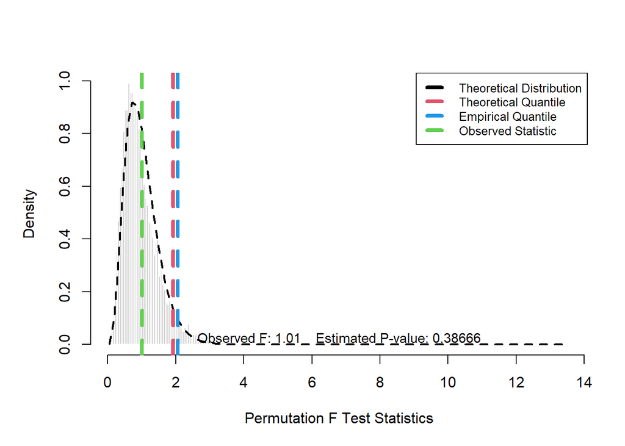

```r
par(mar = c(5, 5, 4, 2) + 0.1, mgp = c(3, 1, 0))

hist(f_permuted, "FD", freq = FALSE, main = NA,
     xlab = "Permutation F Test Statistics", ylab = "Density",
     col = "lightgray", border = "white")
curve(df(x, df_f1, df_f2), add = TRUE, lty = 2, lwd = 2, col = 1)
abline(v = qf(1 - alpha, df_f1, df_f2), col = 2, lty = 2, lwd = 4)
abline(v = quantile(f_permuted, 1 - alpha), col = 4, lty = 2, lwd = 4)
abline(v = f_observed, col = 3, lty = 2, lwd = 4)

legend("topright",
       c("Theoretical Distribution", "Theoretical Quantile",
         "Empirical Quantile", "Observed Statistic"),
       col = c(1, 2, 4, 3), lty = rep(2, 4), lwd = rep(4, 4),
       cex = 0.8, bg = "white")

mtext(text = paste("Observed F:", round(f_observed, 2),
                   "   Estimated P-value:", round(p_val_F_precise, 5)),
      side = 1, line = -1.5, adj = 0.5, outer = FALSE, cex = 0.9, col = "black")
```

```r
model_reduced <- lm(area ~ . - wind, data = df_quant)
y_hat_reduced <- fitted(model_reduced)
res_reduced <- residuals(model_reduced)
t_observed <- summary(ols_model)$coefficients["wind", "t value"]
df_t <- summary(ols_model)$df[2]
t_permuted_res <- numeric(B)

for (i in 1:B) {
  res_star <- sample(res_reduced)
  y_star <- y_hat_reduced + res_star
  temp_data <- df_quant
  temp_data$area <- y_star
  model_star <- lm(area ~ ., data = temp_data)
  t_permuted_res[i] <- summary(model_star)$coefficients["wind", "t value"]
}

p_val_t_wind_precise <- (1 + sum(abs(t_permuted_res) >= abs(t_observed))) / (1 + B)
print(p_val_t_wind_precise)
```

```
## [1] 0.4175582
```

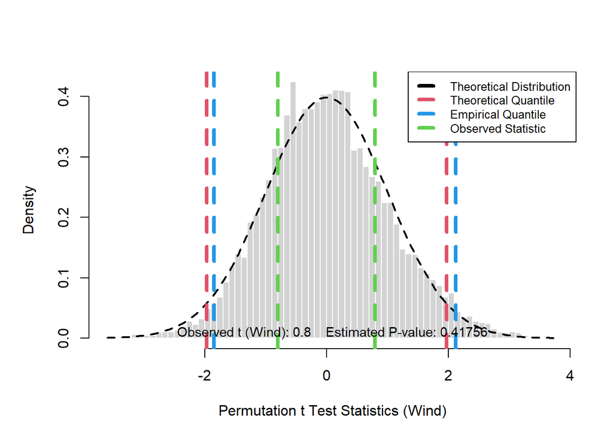

```r
par(mar = c(5, 5, 4, 2) + 0.1, mgp = c(3, 1, 0))

hist(t_permuted_res, "FD", freq = FALSE, main = NA,
     xlab = "Permutation t Test Statistics (Wind)", ylab = "Density",
     col = "lightgray", border = "white")

curve(dt(x, df = df_t), add = TRUE, lty = 2, lwd = 2, col = 1)
abline(v = c(qt(alpha/2, df = df_t), qt(1 - alpha/2, df = df_t)), col = 2, lty = 2, lwd = 4)
abline(v = c(quantile(t_permuted_res, alpha/2), quantile(t_permuted_res, 1 - alpha/2)), col = 4, lty = 2, lwd = 4)
abline(v = c(t_observed, -t_observed), col = 3, lty = 2, lwd = 4)
legend("topright",
       c("Theoretical Distribution", "Theoretical Quantile",
         "Empirical Quantile", "Observed Statistic"),
       col = c(1, 2, 4, 3), lty = rep(2, 4), lwd = rep(4, 4),
       cex = 0.8, bg = "white")
mtext(text = paste("Observed t (Wind):", round(t_observed, 2),
                   "   Estimated P-value:", round(p_val_t_wind_precise, 5)),
      side = 1, line = -1.5, adj = 0.5, outer = FALSE, cex = 0.9, col = "black")
```

## Transformation

Transformation is vital for our data.

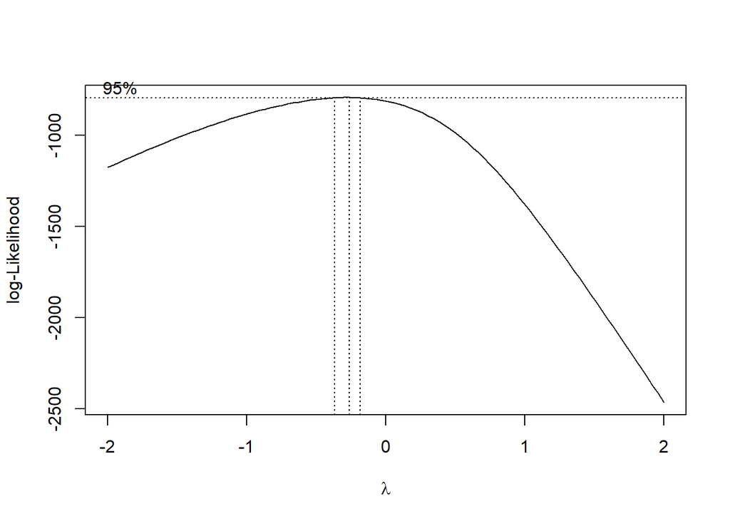

```r
library(MASS)

bc <- boxcox(lm(I(area + 1) ~ ., data = df_quant),
             lambda = seq(-2, 2, 0.1), plotit = TRUE)
```

```r
best_lambda <- bc$x[which.max(bc$y)]

if (abs(best_lambda) < 0.1) {
  df_quant$trans_area <- log(df_quant$area + 1)
} else {
  df_quant$trans_area <- ((df_quant$area + 1)^best_lambda - 1) / best_lambda
}
print(best_lambda)
```

```
## [1] -0.2626263
```

Although the area in this data set is strictly larger than 0, `log(area + 1)` is more stable and is also easier to compare with the original forest fire data set, where zero burned areas can occur.

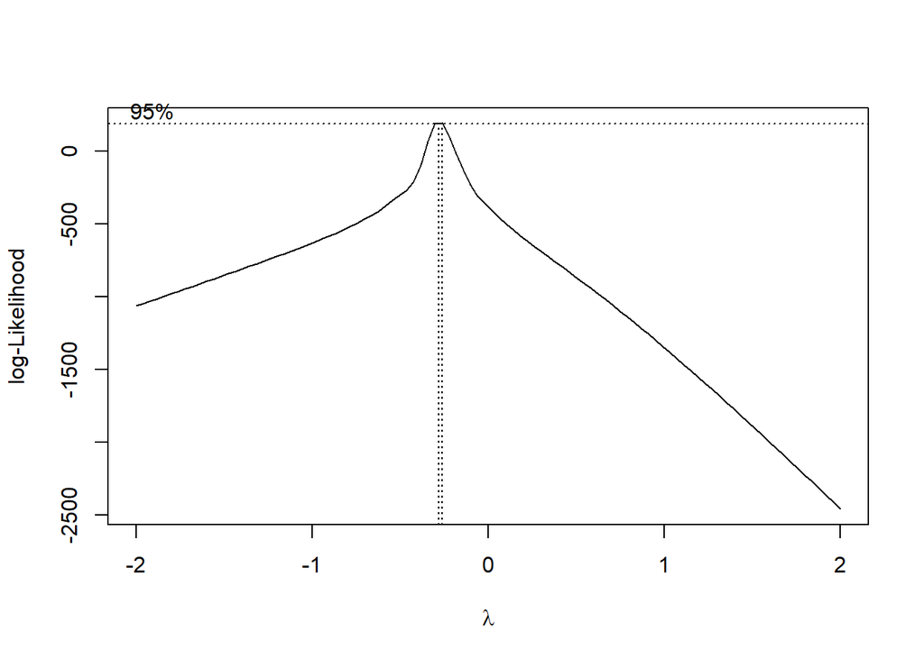

```r
bc <- boxcox(lm(I(area + 1) ~ ., data = df_quant),
             lambda = seq(-2, 2, 0.1), plotit = TRUE)
```

```r
best_lambda <- bc$x[which.max(bc$y)]

if (abs(best_lambda) < 0.1) {
  df_quant$trans_area <- log1p(df_quant$area)
} else {
  df_quant$trans_area <- ((df_quant$area + 1)^best_lambda - 1) / best_lambda
}
print(best_lambda)
```

```
## [1] -0.2626263
```

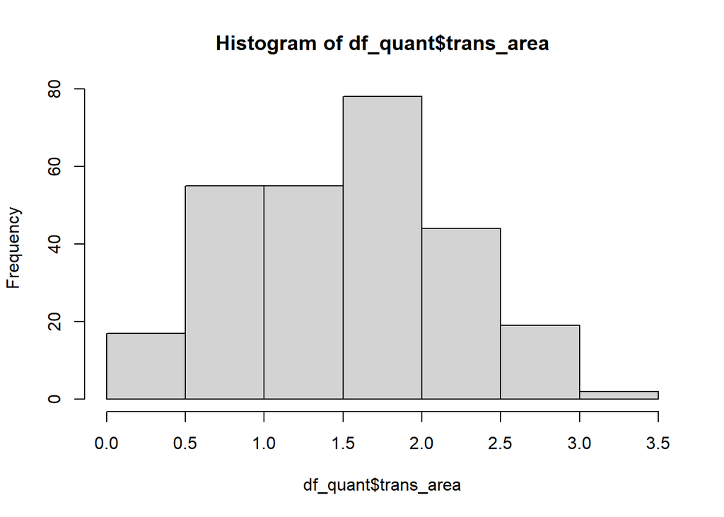

```r
hist(df_quant$trans_area)
```

```r
ols_trans <- lm(trans_area ~ . - area, data = df_quant)
summary(ols_trans)
```

```
##
## Call:
## lm(formula = trans_area ~ . - area, data = df_quant)
##
## Residuals:
##     Min      1Q  Median      3Q     Max
## -1.4293 -0.5014 -0.0040  0.4459  1.6383
##
## Coefficients:
##               Estimate Std. Error t value Pr(>|t|)
## (Intercept)  1.7592657  1.6043654   1.097   0.2739
## X            0.0110454  0.0201601   0.548   0.5842
## Y           -0.0297738  0.0408475  -0.729   0.4667
## FFMC         0.0025621  0.0180442   0.142   0.8872
## DMC          0.0017585  0.0010143   1.734   0.0842 .
## DC          -0.0001871  0.0002512  -0.745   0.4570
## ISI         -0.0238856  0.0151072  -1.581   0.1151
## temp        -0.0077320  0.0108517  -0.713   0.4768
## RH          -0.0052202  0.0034761  -1.502   0.1344
## wind         0.0257455  0.0244162   1.054   0.2927
## ---
## Signif. codes:  0 '***' 0.001 '**' 0.01 '*' 0.05 '.' 0.1 ' ' 1
##
## Residual standard error: 0.6698 on 260 degrees of freedom
## Multiple R-squared:  0.03549,    Adjusted R-squared:  0.002103
## F-statistic: 1.063 on 9 and 260 DF,  p-value: 0.3907
```

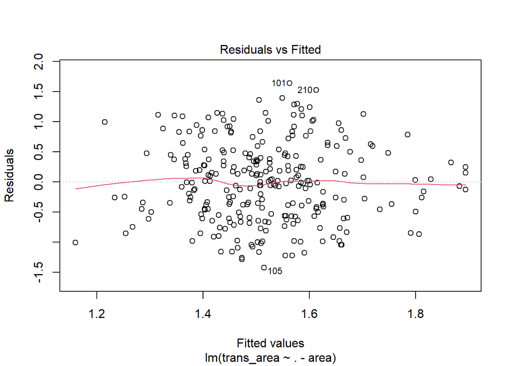

```r
plot(ols_trans, which = 1)
```

### Transformation of Covariates

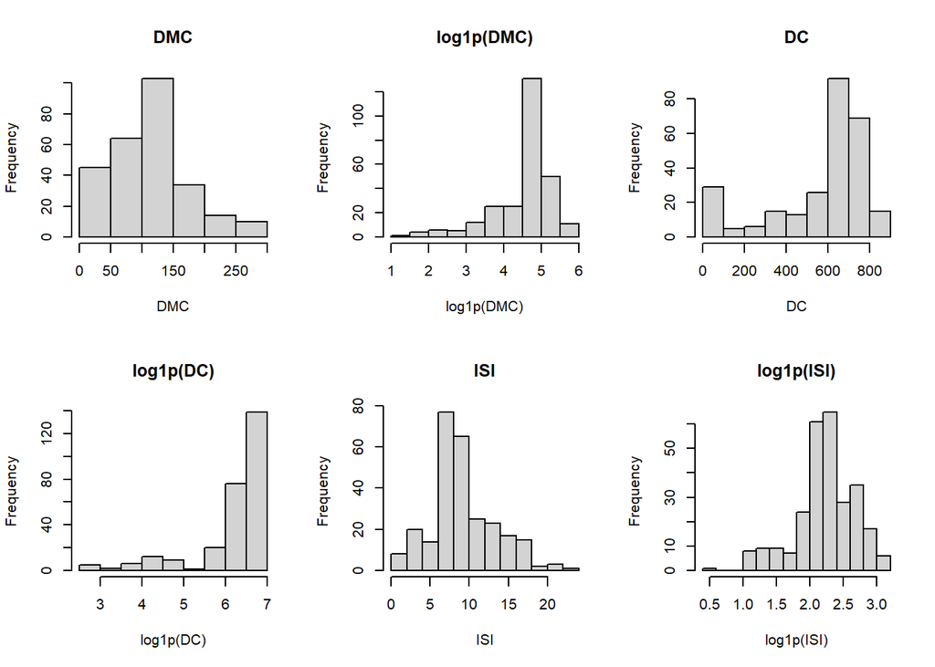

```r
df_trans <- df

df_trans$log_area <- log1p(df_trans$area)
df_trans$log_DMC <- log1p(df_trans$DMC)
df_trans$log_DC <- log1p(df_trans$DC)
df_trans$log_ISI <- log1p(df_trans$ISI)
df_trans$log_wind <- log1p(df_trans$wind)
df_trans$log_FFMC_deficit <- log(pmax(100 - df_trans$FFMC, .Machine$double.eps))

par(mfrow = c(2, 3))
hist(df_trans$DMC, main = "DMC", xlab = "DMC")
hist(df_trans$log_DMC, main = "log1p(DMC)", xlab = "log1p(DMC)")
hist(df_trans$DC, main = "DC", xlab = "DC")
hist(df_trans$log_DC, main = "log1p(DC)", xlab = "log1p(DC)")
hist(df_trans$ISI, main = "ISI", xlab = "ISI")
hist(df_trans$log_ISI, main = "log1p(ISI)", xlab = "log1p(ISI)")
```

```r
par(mfrow = c(1, 1))
```

Now we compare the original transformed-response model with a model that also transforms the skewed covariates.

```r
model_log_y <- lm(log_area ~ X + Y + FFMC + DMC + DC + ISI + temp + RH + wind,
                  data = df_trans)

model_log_yx <- lm(log_area ~ X + Y + log_FFMC_deficit + log_DMC +
                     log_DC + log_ISI + temp + RH + log_wind,
                   data = df_trans)

model_compare <- data.frame(
  Model = c("log area only", "log area and selected covariates"),
  R_squared = c(summary(model_log_y)$r.squared,
                summary(model_log_yx)$r.squared),
  Adj_R_squared = c(summary(model_log_y)$adj.r.squared,
                    summary(model_log_yx)$adj.r.squared),
  AIC = c(AIC(model_log_y), AIC(model_log_yx)),
  BIC = c(BIC(model_log_y), BIC(model_log_yx))
)
print(model_compare)
```

```
##                              Model  R_squared Adj_R_squared      AIC      BIC
## 1                    log area only 0.03432559  0.0008984003 901.4710 941.0536
## 2 log area and selected covariates 0.03547372  0.0020862719 901.1498 940.7324
```

```r
summary(model_log_yx)
```

```
##
## Call:
## lm(formula = log_area ~ X + Y + log_FFMC_deficit + log_DMC +
##     log_DC + log_ISI + temp + RH + log_wind, data = df_trans)
##
## Residuals:
##     Min      1Q  Median      3Q     Max
## -1.9612 -0.9427 -0.1797  0.6675  4.7037
##
## Coefficients:
##                   Estimate Std. Error t value Pr(>|t|)
## (Intercept)       4.407942   1.934011   2.279   0.0235 *
## X                 0.032429   0.037776   0.858   0.3914
## Y                -0.055422   0.076333  -0.726   0.4685
## log_FFMC_deficit -0.468095   0.498977  -0.938   0.3491
## log_DMC           0.326565   0.224580   1.454   0.1471
## log_DC           -0.168275   0.167138  -1.007   0.3150
## log_ISI          -0.721061   0.348259  -2.070   0.0394 *
## temp             -0.009746   0.020742  -0.470   0.6388
## RH               -0.008774   0.006411  -1.369   0.1723
## log_wind          0.341346   0.217388   1.570   0.1176
## ---
## Signif. codes:  0 '***' 0.001 '**' 0.01 '*' 0.05 '.' 0.1 ' ' 1
##
## Residual standard error: 1.256 on 260 degrees of freedom
## Multiple R-squared:  0.03547,    Adjusted R-squared:  0.002086
## F-statistic: 1.062 on 9 and 260 DF,  p-value: 0.391
```

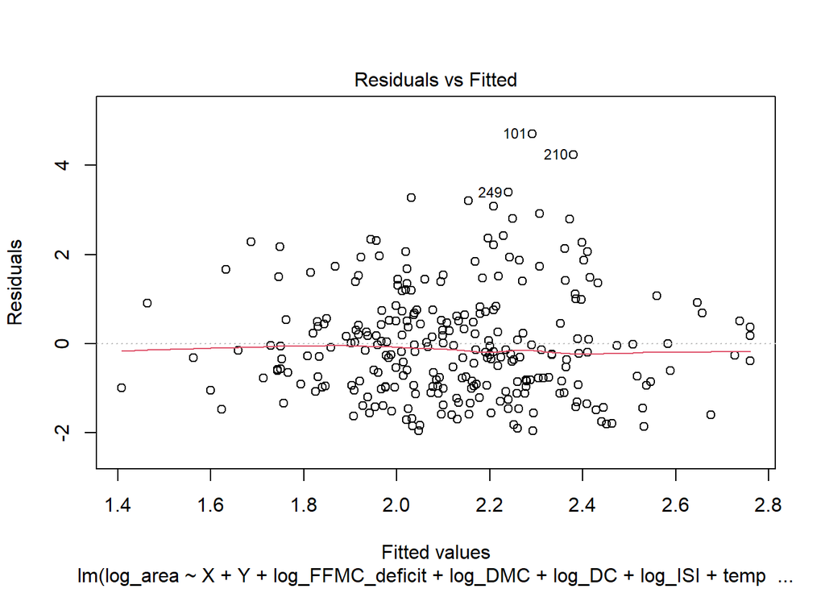

```r
plot(model_log_yx, which = 1)
```

### Month and Day Effects

The variables `month` and `day` are qualitative variables. A natural first choice is to include them as fixed effects. This lets each month and each weekday have its own intercept shift.

```r
df_trans$month_fac <- factor(df_trans$month,
                             levels = tolower(month.abb),
                             ordered = FALSE)
df_trans$day_fac <- factor(df_trans$day,
                           levels = c("mon", "tue", "wed", "thu", "fri", "sat", "sun"),
                           ordered = FALSE)

model_with_factors <- lm(log_area ~ X + Y + log_FFMC_deficit + log_DMC +
                           log_DC + log_ISI + temp + RH + log_wind +
                           month_fac + day_fac,
                         data = df_trans)

summary(model_with_factors)
```

```
##
## Call:
## lm(formula = log_area ~ X + Y + log_FFMC_deficit + log_DMC +
##     log_DC + log_ISI + temp + RH + log_wind + month_fac + day_fac,
##     data = df_trans)
##
## Residuals:
##     Min      1Q  Median      3Q     Max
## -2.1302 -0.8727 -0.0931  0.5617  4.2390
##
## Coefficients:
##                   Estimate Std. Error t value Pr(>|t|)
## (Intercept)       3.663273   2.549210   1.437  0.15199
## X                 0.045893   0.038961   1.178  0.23996
## Y                -0.057874   0.078244  -0.740  0.46021
## log_FFMC_deficit -0.327734   0.509083  -0.644  0.52032
## log_DMC           0.802017   0.283456   2.829  0.00505 **
## log_DC           -0.715517   0.532233  -1.344  0.18007
## log_ISI          -0.445107   0.366587  -1.214  0.22584
## temp              0.024791   0.028587   0.867  0.38669
## RH               -0.001855   0.007972  -0.233  0.81622
## log_wind          0.333056   0.229573   1.451  0.14813
## month_facmar     -0.611045   0.718885  -0.850  0.39616
## month_facapr      0.027527   0.781782   0.035  0.97194
## month_facmay      1.139184   1.395620   0.816  0.41515
## month_facjun     -0.799000   1.247828  -0.640  0.52257
## month_facjul     -0.646173   1.348828  -0.479  0.63232
## month_facaug     -0.578968   1.496020  -0.387  0.69909
## month_facsep      0.105708   1.556137   0.068  0.94590
## month_facoct      1.349547   1.656725   0.815  0.41610
## month_facdec      1.207014   1.392924   0.867  0.38705
## day_factue        0.330096   0.306440   1.077  0.28245
## day_facwed        0.106825   0.314751   0.339  0.73460
## day_facthu        0.142092   0.316623   0.449  0.65399
## day_facfri        0.030519   0.300126   0.102  0.91909
## day_facsat        0.582533   0.286159   2.036  0.04286 *
## day_facsun        0.381920   0.285478   1.338  0.18219
## ---
## Signif. codes:  0 '***' 0.001 '**' 0.01 '*' 0.05 '.' 0.1 ' ' 1
##
## Residual standard error: 1.239 on 245 degrees of freedom
## Multiple R-squared:  0.1157, Adjusted R-squared:  0.0291
## F-statistic: 1.336 on 24 and 245 DF,  p-value: 0.141
```

Month is also seasonal. December and January are close in time, but a factor model does not know that. A second approach is to transform month into sine and cosine terms, which captures a smooth yearly cycle using only two parameters.

```r
df_trans$month_num <- match(df_trans$month, tolower(month.abb))
df_trans$month_sin <- sin(2 * pi * df_trans$month_num / 12)
df_trans$month_cos <- cos(2 * pi * df_trans$month_num / 12)

model_with_cycle_month <- lm(log_area ~ X + Y + log_FFMC_deficit + log_DMC +
                               log_DC + log_ISI + temp + RH + log_wind +
                               month_sin + month_cos + day_fac,
                             data = df_trans)

season_compare <- data.frame(
  Model = c("no month/day", "month/day as factors", "cyclic month + day factor"),
  R_squared = c(summary(model_log_yx)$r.squared,
                summary(model_with_factors)$r.squared,
                summary(model_with_cycle_month)$r.squared),
  Adj_R_squared = c(summary(model_log_yx)$adj.r.squared,
                    summary(model_with_factors)$adj.r.squared,
                    summary(model_with_cycle_month)$adj.r.squared),
  AIC = c(AIC(model_log_yx),
          AIC(model_with_factors),
          AIC(model_with_cycle_month)),
  BIC = c(BIC(model_log_yx),
          BIC(model_with_factors),
          BIC(model_with_cycle_month))
)
print(season_compare)
```

```
##                       Model  R_squared Adj_R_squared      AIC       BIC
## 1              no month/day 0.03547372   0.002086272 901.1498  940.7324
## 2      month/day as factors 0.11572542   0.029102602 907.6950 1001.2540
## 3 cyclic month + day factor 0.08459408   0.022840510 903.0370  971.4070
```

```r
summary(model_with_cycle_month)
```

```
##
## Call:
## lm(formula = log_area ~ X + Y + log_FFMC_deficit + log_DMC +
##     log_DC + log_ISI + temp + RH + log_wind + month_sin + month_cos +
##     day_fac, data = df_trans)
##
## Residuals:
##     Min      1Q  Median      3Q     Max
## -2.1627 -0.8678 -0.1247  0.6188  4.2187
##
## Coefficients:
##                   Estimate Std. Error t value Pr(>|t|)
## (Intercept)       3.860262   2.541725   1.519   0.1301
## X                 0.049431   0.038347   1.289   0.1986
## Y                -0.055716   0.076609  -0.727   0.4677
## log_FFMC_deficit -0.380263   0.505782  -0.752   0.4529
## log_DMC           0.522034   0.246038   2.122   0.0348 *
## log_DC           -0.457741   0.352178  -1.300   0.1949
## log_ISI          -0.555430   0.359499  -1.545   0.1236
## temp              0.015391   0.026362   0.584   0.5599
## RH               -0.004763   0.007511  -0.634   0.5265
## log_wind          0.354915   0.221278   1.604   0.1100
## month_sin        -0.166120   0.411462  -0.404   0.6868
## month_cos         0.735304   0.287333   2.559   0.0111 *
## day_factue        0.252516   0.301979   0.836   0.4038
## day_facwed        0.007552   0.311835   0.024   0.9807
## day_facthu        0.077670   0.312490   0.249   0.8039
## day_facfri        0.012719   0.291112   0.044   0.9652
## day_facsat        0.503131   0.284718   1.767   0.0784 .
## day_facsun        0.316637   0.281725   1.124   0.2621
## ---
## Signif. codes:  0 '***' 0.001 '**' 0.01 '*' 0.05 '.' 0.1 ' ' 1
##
## Residual standard error: 1.243 on 252 degrees of freedom
## Multiple R-squared:  0.08459,    Adjusted R-squared:  0.02284
## F-statistic:  1.37 on 17 and 252 DF,  p-value: 0.1516
```

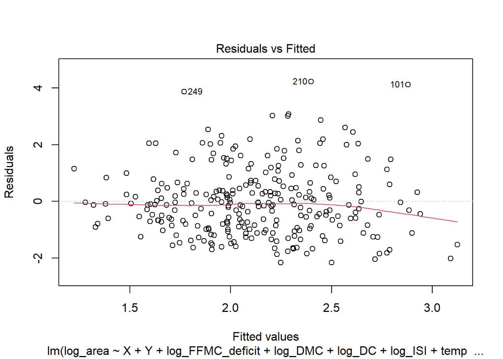

```r
plot(model_with_cycle_month, which = 1)
```

If the factor model has a much better AIC/BIC and adjusted R-squared, then month-specific effects are useful. If the cyclic model performs similarly, it is preferable because it uses fewer parameters and has a clearer seasonal interpretation.

The full month and day factor model improves the unadjusted R-squared, but it also uses many parameters. Since the adjusted R-squared, AIC, and BIC do not clearly improve, a lower-dimensional version of these calendar variables is more appropriate.

```r
df_trans$weekend <- ifelse(df_trans$day %in% c("fri", "sat", "sun"), 1, 0)
df_trans$summer <- ifelse(df_trans$month %in% c("jun", "jul", "aug", "sep"), 1, 0)

model_with_calendar_indicators <- lm(log_area ~ X + Y + log_FFMC_deficit +
                                       log_DMC + log_DC + log_ISI + temp + RH +
                                       log_wind + weekend + summer,
                                     data = df_trans)

calendar_compare <- data.frame(
  Model = c("no calendar variables",
            "full month/day factors",
            "cyclic month + day factor",
            "weekend + summer indicators"),
  Number_of_parameters = c(length(coef(model_log_yx)),
                           length(coef(model_with_factors)),
                           length(coef(model_with_cycle_month)),
                           length(coef(model_with_calendar_indicators))),
  R_squared = c(summary(model_log_yx)$r.squared,
                summary(model_with_factors)$r.squared,
                summary(model_with_cycle_month)$r.squared,
                summary(model_with_calendar_indicators)$r.squared),
  Adj_R_squared = c(summary(model_log_yx)$adj.r.squared,
                    summary(model_with_factors)$adj.r.squared,
                    summary(model_with_cycle_month)$adj.r.squared,
                    summary(model_with_calendar_indicators)$adj.r.squared),
  AIC = c(AIC(model_log_yx),
          AIC(model_with_factors),
          AIC(model_with_cycle_month),
          AIC(model_with_calendar_indicators)),
  BIC = c(BIC(model_log_yx),
          BIC(model_with_factors),
          BIC(model_with_cycle_month),
          BIC(model_with_calendar_indicators))
)
print(calendar_compare)
```

```
##                         Model Number_of_parameters  R_squared Adj_R_squared
## 1       no calendar variables                   10 0.03547372   0.002086272
## 2      full month/day factors                   25 0.11572542   0.029102602
## 3   cyclic month + day factor                   18 0.08459408   0.022840510
## 4 weekend + summer indicators                   12 0.05623903   0.016001163
##        AIC       BIC
## 1 901.1498  940.7324
## 2 907.6950 1001.2540
## 3 903.0370  971.4070
## 4 899.2735  946.0530
```

```r
summary(model_with_calendar_indicators)
```

```
##
## Call:
## lm(formula = log_area ~ X + Y + log_FFMC_deficit + log_DMC +
##     log_DC + log_ISI + temp + RH + log_wind + weekend + summer,
##     data = df_trans)
##
## Residuals:
##     Min      1Q  Median      3Q     Max
## -2.1286 -0.9168 -0.1771  0.5660  4.6223
##
## Coefficients:
##                   Estimate Std. Error t value Pr(>|t|)
## (Intercept)       3.157502   2.078562   1.519   0.1300
## X                 0.033399   0.037528   0.890   0.3743
## Y                -0.065653   0.076330  -0.860   0.3905
## log_FFMC_deficit -0.453770   0.499350  -0.909   0.3643
## log_DMC           0.387335   0.227599   1.702   0.0900 .
## log_DC            0.016762   0.188949   0.089   0.9294
## log_ISI          -0.687633   0.349075  -1.970   0.0499 *
## temp              0.007906   0.023153   0.341   0.7330
## RH               -0.005322   0.007004  -0.760   0.4481
## log_wind          0.259085   0.219067   1.183   0.2380
## weekend           0.215444   0.157668   1.366   0.1730
## summer           -0.844203   0.444778  -1.898   0.0588 .
## ---
## Signif. codes:  0 '***' 0.001 '**' 0.01 '*' 0.05 '.' 0.1 ' ' 1
##
## Residual standard error: 1.247 on 258 degrees of freedom
## Multiple R-squared:  0.05624,    Adjusted R-squared:  0.016
## F-statistic: 1.398 on 11 and 258 DF,  p-value: 0.1739
```

The weekend indicator is motivated by the idea that human activity may be different on weekends. However, because the response variable here is burned area rather than fire occurrence, this variable should be interpreted carefully: it tests whether fires that occur around the weekend tend to have different burned areas, not whether fires are more likely to occur on weekends.

### Model Selection

Since the full model with month and day factors uses many parameters, we use model selection to balance fit and model complexity. AIC tends to keep more variables, while BIC penalizes model size more heavily.

```r
full_factor_model <- lm(log_area ~ X + Y + log_FFMC_deficit + log_DMC +
                          log_DC + log_ISI + temp + RH + log_wind +
                          weekend + summer + month_sin + month_cos,
                        data = df_trans)

null_model <- lm(log_area ~ 1, data = df_trans)

step_aic_model <- step(null_model,
                       scope = list(lower = null_model,
                                    upper = full_factor_model),
                       direction = "both",
                       trace = FALSE)

step_bic_model <- step(null_model,
                       scope = list(lower = null_model,
                                    upper = full_factor_model),
                       direction = "both",
                       k = log(nrow(df_trans)),
                       trace = FALSE)

selection_compare <- data.frame(
  Model = c("candidate calendar model", "stepwise AIC", "stepwise BIC"),
  Number_of_parameters = c(length(coef(full_factor_model)),
                           length(coef(step_aic_model)),
                           length(coef(step_bic_model))),
  R_squared = c(summary(full_factor_model)$r.squared,
                summary(step_aic_model)$r.squared,
                summary(step_bic_model)$r.squared),
  Adj_R_squared = c(summary(full_factor_model)$adj.r.squared,
                    summary(step_aic_model)$adj.r.squared,
                    summary(step_bic_model)$adj.r.squared),
  AIC = c(AIC(full_factor_model),
          AIC(step_aic_model),
          AIC(step_bic_model)),
  BIC = c(BIC(full_factor_model),
          BIC(step_aic_model),
          BIC(step_bic_model))
)
print(selection_compare)
```

```
##                      Model Number_of_parameters  R_squared Adj_R_squared
## 1 candidate calendar model                   14 0.07656961    0.02967666
## 2             stepwise AIC                    2 0.01739909    0.01373267
## 3             stepwise BIC                    1 0.00000000    0.00000000
##        AIC      BIC
## 1 897.3935 951.3699
## 2 890.1626 900.9579
## 3 892.9017 900.0985
```

```r
summary(step_aic_model)
```

```
##
## Call:
## lm(formula = log_area ~ month_cos, data = df_trans)
##
## Residuals:
##     Min      1Q  Median      3Q     Max
## -1.9310 -0.9312 -0.2318  0.5945  4.7814
##
## Coefficients:
##             Estimate Std. Error t value Pr(>|t|)
## (Intercept)   2.2142     0.0858  25.806   <2e-16 ***
## month_cos     0.3940     0.1809   2.178   0.0302 *
## ---
## Signif. codes:  0 '***' 0.001 '**' 0.01 '*' 0.05 '.' 0.1 ' ' 1
##
## Residual standard error: 1.249 on 268 degrees of freedom
## Multiple R-squared:  0.0174, Adjusted R-squared:  0.01373
## F-statistic: 4.746 on 1 and 268 DF,  p-value: 0.03025
```

```r
summary(step_bic_model)
```

```
##
## Call:
## lm(formula = log_area ~ 1, data = df_trans)
##
## Residuals:
##     Min      1Q  Median      3Q     Max
## -2.0412 -0.9832 -0.1300  0.6712  4.8682
##
## Coefficients:
##             Estimate Std. Error t value Pr(>|t|)
## (Intercept)  2.12741    0.07652    27.8   <2e-16 ***
## ---
## Signif. codes:  0 '***' 0.001 '**' 0.01 '*' 0.05 '.' 0.1 ' ' 1
##
## Residual standard error: 1.257 on 269 degrees of freedom
```

We can also compare the selected models to the low-dimensional calendar model. If the selected model removes all covariates, that indicates that the linear signal is weak and that the model with many fire weather and calendar variables may be overfitting.

```r
final_compare <- data.frame(
  Model = c("stepwise AIC", "stepwise BIC", "weekend + summer model"),
  Number_of_parameters = c(length(coef(step_aic_model)),
                           length(coef(step_bic_model)),
                           length(coef(model_with_calendar_indicators))),
  R_squared = c(summary(step_aic_model)$r.squared,
                summary(step_bic_model)$r.squared,
                summary(model_with_calendar_indicators)$r.squared),
  Adj_R_squared = c(summary(step_aic_model)$adj.r.squared,
                    summary(step_bic_model)$adj.r.squared,
                    summary(model_with_calendar_indicators)$adj.r.squared),
  AIC = c(AIC(step_aic_model),
          AIC(step_bic_model),
          AIC(model_with_calendar_indicators)),
  BIC = c(BIC(step_aic_model),
          BIC(step_bic_model),
          BIC(model_with_calendar_indicators))
)
print(final_compare)
```

```
##                    Model Number_of_parameters  R_squared Adj_R_squared      AIC
## 1           stepwise AIC                    2 0.01739909    0.01373267 890.1626
## 2           stepwise BIC                    1 0.00000000    0.00000000 892.9017
## 3 weekend + summer model                   12 0.05623903    0.01600116 899.2735
##        BIC
## 1 900.9579
## 2 900.0985
## 3 946.0530
```

```r
final_model <- step_aic_model
summary(final_model)
```

```
##
## Call:
## lm(formula = log_area ~ month_cos, data = df_trans)
##
## Residuals:
##     Min      1Q  Median      3Q     Max
## -1.9310 -0.9312 -0.2318  0.5945  4.7814
##
## Coefficients:
##             Estimate Std. Error t value Pr(>|t|)
## (Intercept)   2.2142     0.0858  25.806   <2e-16 ***
## month_cos     0.3940     0.1809   2.178   0.0302 *
## ---
## Signif. codes:  0 '***' 0.001 '**' 0.01 '*' 0.05 '.' 0.1 ' ' 1
##
## Residual standard error: 1.249 on 268 degrees of freedom
## Multiple R-squared:  0.0174, Adjusted R-squared:  0.01373
## F-statistic: 4.746 on 1 and 268 DF,  p-value: 0.03025
```

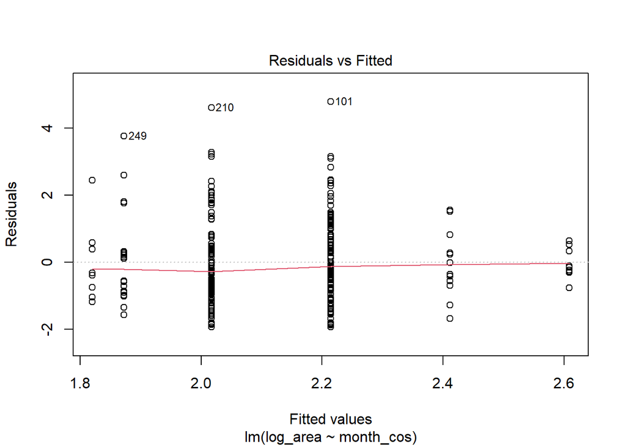

```r
plot(final_model, which = 1)
```

The AIC-selected model keeps only `month_cos`, while the BIC-selected model keeps no covariates. This suggests that there is weak evidence of a seasonal pattern in burned area, but the overall explanatory power of the linear model is very limited. Therefore, the final model should be interpreted mainly as a descriptive model rather than a strong prediction model.

The `weekend` variable is not statistically significant in this model for burned area. This does not contradict the idea that fires may occur more often on weekends, because occurrence probability and burned area are different outcomes.